# Accounting for uncertainty in simulation greenhouse gas emissions from dairy cattle in Kenya

# 12 Sensitivity analysis - which uncertainties matter?

To identify influential variables in the population that are particularly strongly related to emissions intensity, we can use the statistical procedure of Projection-to-Latent-Structures (PLS) regression. Based on the Variable-Importance-in-the-Projection (VIP) score, we can see, for which uncertain variables knowledge gains would be particularly fruitful.

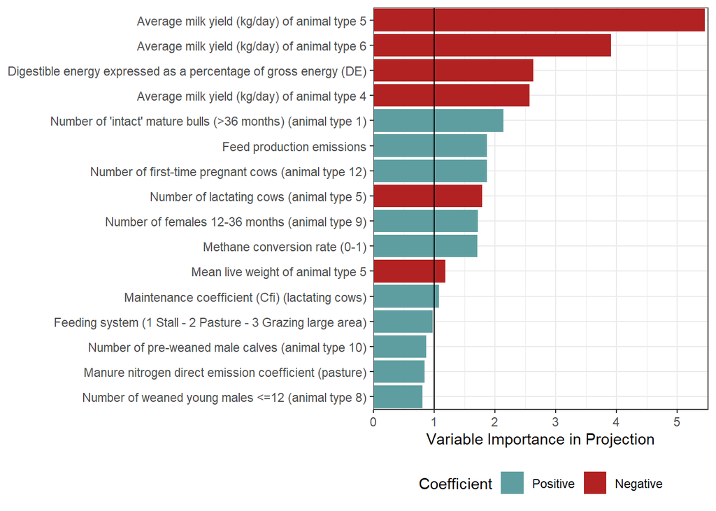

```r
pls_GHG<-dairy_households
pls_GHG$x<-pls_GHG$x[,which(!colnames(pls_GHG$x)=="Scenario")]

pls_out<-plsr.mcSimulation(object=pls_GHG, resultName = "CO2eq_per_milk")

legend_table<-read.csv("data/legend.csv", fileEncoding = "UTF-8-BOM")

plot_pls(pls_out,input_table=legend_table)
```

```r
ggsave("Fig_33_PLS_dairy_households.png", width=8,height=5)
```

# 13 Discussion

- considerable uncertainty in inputs to IPCC equations
- cause major uncertainty in emissions intensity estimates
- this makes it difficult to evaluate the emissions intensity of dairy farms in Kenya based on their milk yield alone - large differences are needed to be certain that one farm is more emissions-efficient than another one
- interventions clearly impact emissions intensity
- emissions intensity savings are substantial for all interventions, but still relatively small in comparison to the overall uncertainty associated with limited knowledge about values of input variables.
- it seems likely that a milk yield-based emissions reduction scheme might miss measures taken by farmers, at least if the reward scheme wants to be really sure that emissions reductions have in fact occurred.
- it seems the information content in milk yields isn’t sufficient to base mitigation reward schemes on them
- might be a better idea after all to observe farmers’ practices - did they implement any measures? Then they should be rewarded
- maybe rewarding measures taken is a better idea than evaluating emissions intensity based on milk yield alone
- sensitivity analysis highlights the need to gain more clarity on milk yields - we specified a 90% confidence interval of mean +- 27.5%
- Improving reliability of milk yield measurements might make this indicator more viable

# 14 Remaining jobs

- Select what to present in the manuscript and the supplement

# References

Dong, Hongmin, James Douglas MacDonald, Stephen Michael Ogle, Maria José Sanz Sanchez, and Marcelo Theoto Rocha. 2019. “Volume 4 - Agriculture, Forestry and Other Land Use.” In *IPCC Refinement to the 2006 IPCC Guidelines for National Greenhouse Gas Inventories*, edited by E. Calvo Buendia, K. Tanabe, A. Baasansuren, M. Fukuda, S. Ngarize, A. Osako, Y. Pyrozhenko, P. Shermanau, and S. Federici. Switzerland: The Intergovernmental Panel on Climate Change. https://www.ipcc-nggip.iges.or.jp/public/2019rf/pdf/4_Volume4/19R_V4_Cover.pdf.

Dong, Hongmin, Joe Mangino, Tim McAllister, Jerry Hatfield, Donald Johnson, Keith Lassey, Magda Aparecida de Lima, and Anna Romanovskaya. 2006. *IPCC Guidelines for National Greenhouse Gas Inventories - Volume 4 Agriculture, Forestry and Other Land Use*. https://www.ipcc-nggip.iges.or.jp/public/2006gl/pdf/4_Volume4/V4_10_Ch10_Livestock.pdf.

IPCC. 2021. *Good Practice Guidance and Uncertainty Management in National Greenhouse Gas Inventories*. Intergovernmental Panel on Climate Change (IPCC). https://www.ipcc-nggip.iges.or.jp/public/gp/english/.

Luedeling, Eike, Lutz Goehring, Katja Schiffers, Cory Whitney, and Eduardo Fernandez. 2022. *decisionSupport: Quantitative Support of Decision Making Under Uncertainty*. http://www.worldagroforestry.org/.

R Core Team. 2021. *R: A Language and Environment for Statistical Computing*. Vienna, Austria: R Foundation for Statistical Computing. https://www.R-project.org/.

Wilkes, Andreas, Charles Odhong, Suzanne van Dijk, Simon Fraval, and Shimels Eshete Wassie. 2019. “Methods and Guidance to Support MRV of Livestock Emissions (Working Paper No. 285).” CGIAR Research Program on Climate Change, Agriculture; Food Security (CCAFS).

Wilkes, Andreas, Shimels Wassie, Charles Odhong’, Simon Fraval, and Suzanne van Dijk. 2020. “Variation in the Carbon Footprint of Milk Production on Smallholder Dairy Farms in Central Kenya.” *Journal of Cleaner Production* 265 (August): 121780. https://doi.org/10.1016/j.jclepro.2020.121780.